# housing price in Davis

Fengsheng Zhou

7/30/2021

**Introduction**

In the research, we are interested in studying the housing price fluctuation in Davis. There are lots of potential factors that affect housing price such as number of bedroom(bedroom), number of bathroom(bathroom), gross living area(GLA), lot size(lot_size), year built(year), number of garage(garage) and the distance to the center of the DownTown of Davis(distance). The goal of this experiment is to find out how the housing price will be affected by the different factor and build a model for the significant variables. The approaches we will take in the project are plot including boxplot, histogram, qq-plot and residual plot, Shapiro-Wilks Test, single factor ANOVA, and so on; meanwhile, the confidence level we assume in this research is 95% and the corresponding alpha value is 0.05.

**Building process**

```r
house <- read.csv("~/Desktop/house.csv")
library(MASS)
library(ggplot2)
library(leaps)
```

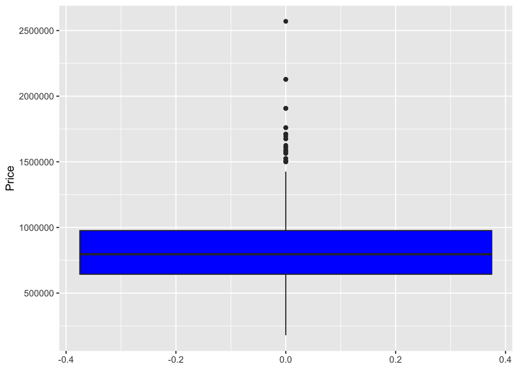

```r
ggplot(data=house,aes(y=Price))+
  geom_boxplot(fill="blue")
```

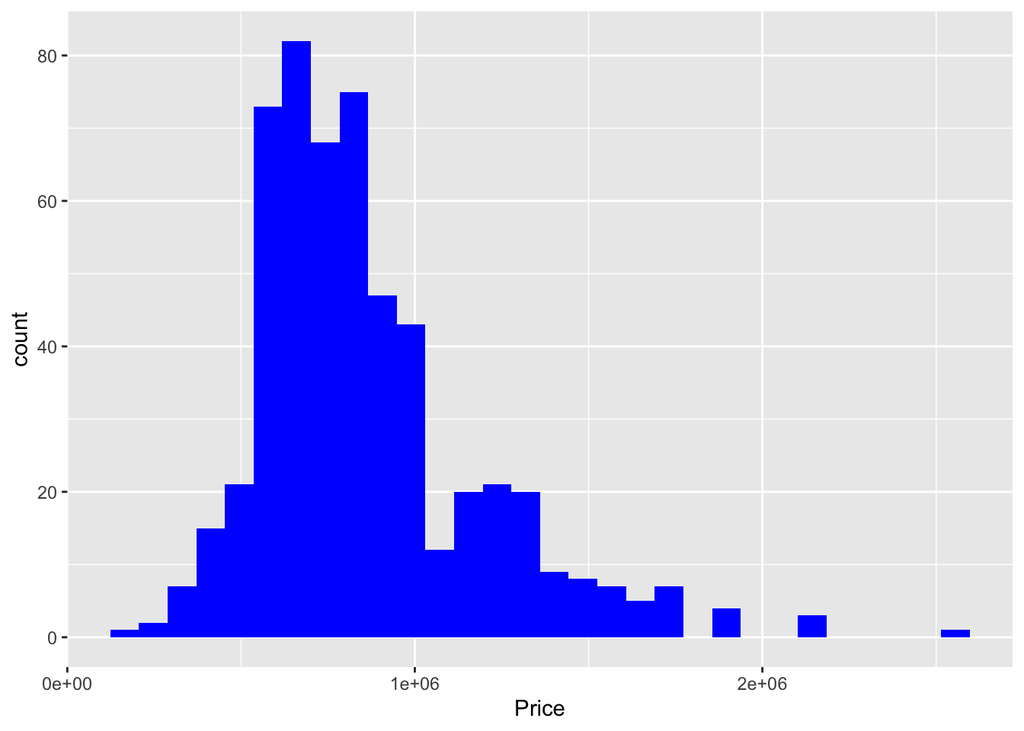

```r
ggplot(data=house,aes(x=Price))+
   geom_histogram(fill="blue")
```

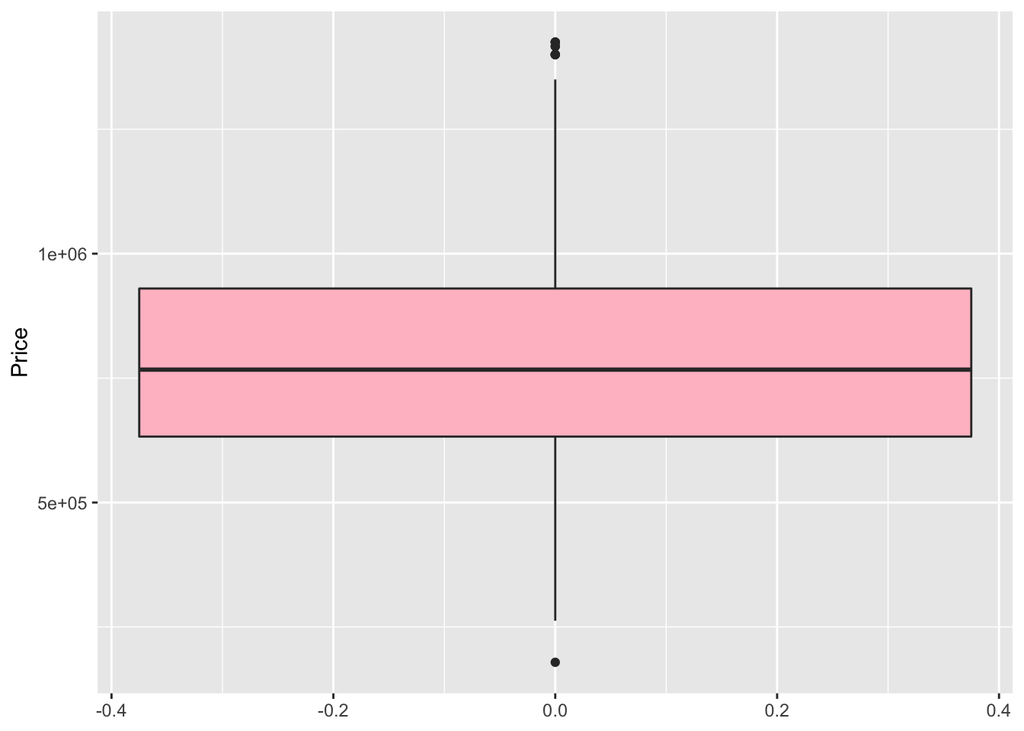

```r
house<-house[house$Price<1500000, ]
ggplot(data=house,aes(y=Price))+
  geom_boxplot(fill="pink")
```

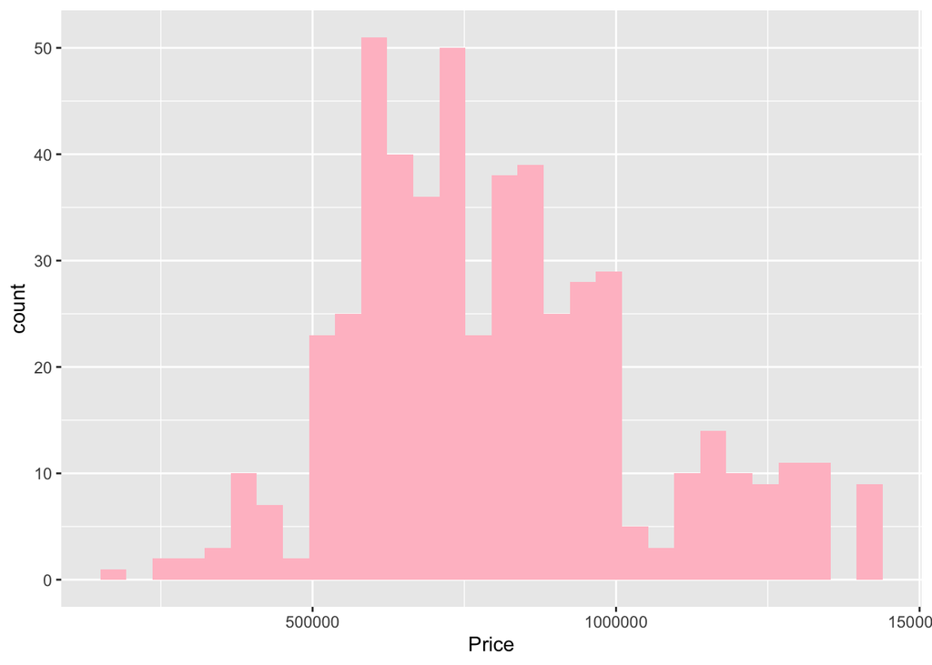

```r
ggplot(data=house,aes(x=Price))+
   geom_histogram(fill="pink")
```

After removing the outliers, I recreate the boxplot and histogram of the housing prices. And without doubt, both of the plots shows a much better performance than the previous plots.

```r
#variable names setup
price<-house$Price
bedroom<-house$Bedrooms
bathroom<-house$Bathrooms
GLA<-house$GrossLivingArea
lotSize<-house$Lot_size
year<-2021-house$Year_built
garage<-house$Garage
distance<-house$Distance
```

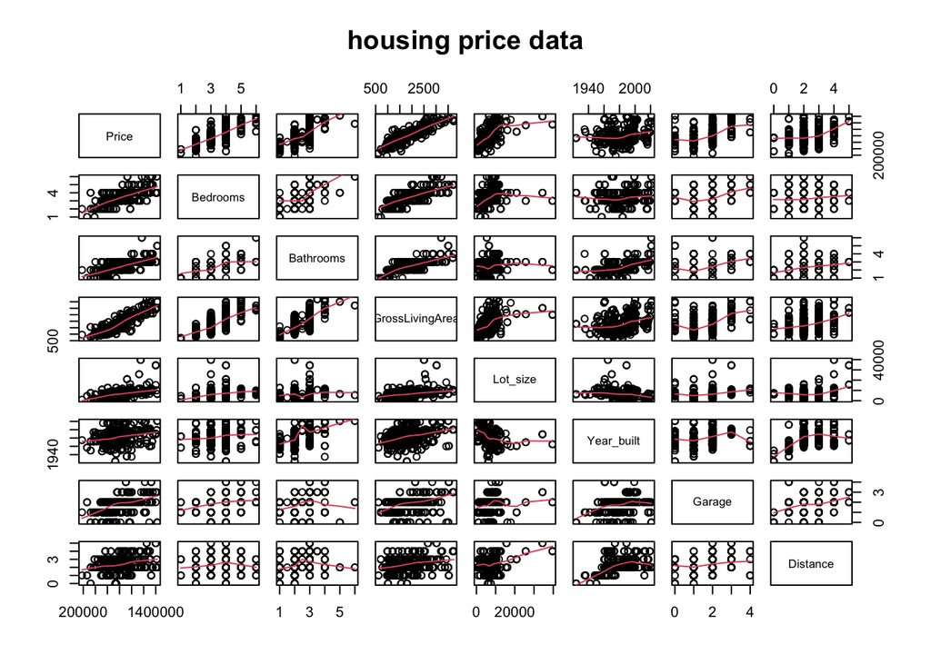

```r
pairs(house[,1:8], panel = panel.smooth, main = "housing price data")
```

From the Scatterplot Matrices, we can observe that most of our variables have a positive linear relationship with the outcome variable, which is the housing price. Although the trend between the price and lot size seems a little bit unclear, it is good enough to show the positive linear relation since there are three obvious outliers in the plot. Therefore, we can build our regression model.

```r
fit1<-lm(price~bedroom+bathroom+GLA+lotSize +year+garage+distance)
summary(fit1)
```

```
##
## Call:
## lm(formula = price ~ bedroom + bathroom + GLA + lotSize + year +
##     garage + distance)
##
## Residuals:
##     Min      1Q  Median      3Q     Max
## -376081  -58065   -1897   55528  284654
##
## Coefficients:
##               Estimate Std. Error t value Pr(>|t|)
## (Intercept) 103727.665  35182.019   2.948 0.003342 **
## bedroom      28620.197   8188.161   3.495 0.000515 ***
## bathroom     24169.772  11052.229   2.187 0.029207 *
## GLA            226.990     15.266  14.869  < 2e-16 ***
## lotSize         11.221      1.383   8.113 3.73e-15 ***
## year           -87.767    377.966  -0.232 0.816469
## garage       32321.732   6238.089   5.181 3.18e-07 ***
## distance      2397.599   6147.820   0.390 0.696706
## ---
## Signif. codes:  0 '***' 0.001 '**' 0.01 '*' 0.05 '.' 0.1 ' ' 1
##
## Residual standard error: 104700 on 508 degrees of freedom
## Multiple R-squared:  0.8137, Adjusted R-squared:  0.8111
## F-statistic: 316.9 on 7 and 508 DF,  p-value: < 2.2e-16
```

```r
anova(fit1)
```

```
## Analysis of Variance Table
##
## Response: price
##            Df     Sum Sq    Mean Sq   F value    Pr(>F)
## bedroom     1 1.4097e+13 1.4097e+13 1284.9468 < 2.2e-16 ***
## bathroom    1 3.0566e+12 3.0566e+12  278.6068 < 2.2e-16 ***
## GLA         1 5.7264e+12 5.7264e+12  521.9650 < 2.2e-16 ***
## lotSize     1 1.1304e+12 1.1304e+12  103.0405 < 2.2e-16 ***
## year        1 2.4396e+10 2.4396e+10    2.2237    0.1365
## garage      1 2.9794e+11 2.9794e+11   27.1571 2.732e-07 ***
## distance    1 1.6686e+09 1.6686e+09    0.1521    0.6967
## Residuals 508 5.5732e+12 1.0971e+10
## ---
## Signif. codes:  0 '***' 0.001 '**' 0.01 '*' 0.05 '.' 0.1 ' ' 1
```

```r
confint(fit1)
```

```
##                    2.5 %       97.5 %
## (Intercept) 34607.495985 172847.83421
## bedroom     12533.370546  44707.02415
## bathroom     2456.067600  45883.47611
## GLA           196.996847    256.98306
## lotSize         8.503903     13.93819
## year         -830.336842    654.80217
## garage      20066.101792  44577.36147
## distance    -9680.684041  14475.88206
```

I build an original regression model including all the variables, which is price=103727.665+28620.197bedroom+24169.772bathroom+226.990GLA+11.221lot_size+ 32321.732Garage+2397.599distance-87.767year.

The R-squared in this model is 0.8137 and adjusted R-squared is 0.8111, which indicates that our model is quite efficient.

The F-statistic number is 316.9 on 7 and 508 DF and the corresponding p-value is < 2.2e-16, which is much smaller than 0.5. It shows the highly linear relationship in our model.

Addtionally, although the values shows our success of the model, the model is not perpect because the data reveals that the variable of year and distance seems not signifcant in the model. We may still need further improvement.

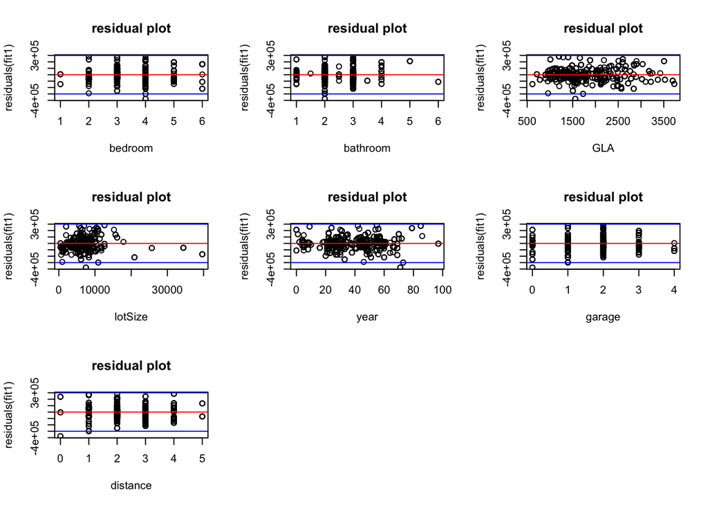

```r
par(mfrow = c(3,3))
plot(bedroom, residuals(fit1), main="residual plot")
abline(h=0, col="red")
abline(h=300000, col="blue")
abline(h=-300000, col="blue")
plot(bathroom, residuals(fit1), main="residual plot")
abline(h=0, col="red")
abline(h=300000, col="blue")
abline(h=-300000, col="blue")
plot(GLA, residuals(fit1), main="residual plot")
abline(h=0, col="red")
abline(h=300000, col="blue")
abline(h=-300000, col="blue")
plot(lotSize, residuals(fit1), main="residual plot")
abline(h=0, col="red")
abline(h=300000, col="blue")
abline(h=-300000, col="blue")
plot(year, residuals(fit1), main="residual plot")
abline(h=0, col="red")
abline(h=300000, col="blue")
abline(h=-300000, col="blue")
plot(garage, residuals(fit1), main="residual plot")
abline(h=0, col="red")
abline(h=300000, col="blue")
abline(h=-300000, col="blue")
plot(distance, residuals(fit1), main="residual plot")
abline(h=0, col="red")
abline(h=300000, col="blue")
abline(h=-300000, col="blue")
```

In order to check the assumption of variance constancy and linearity, I do residual analysis for the individual variables . Form the residual plots, the points nicely fill out this whole space; therefore, there is no violation of linearity. And the points distribute pretty evenly around the h=0; so, there is no violation of constant variance. Since there is 4 obvious outliers in the residual plot of lot size, the plot should be good without them. Therefore, we fullfill the assumption of constant variance and linearity.

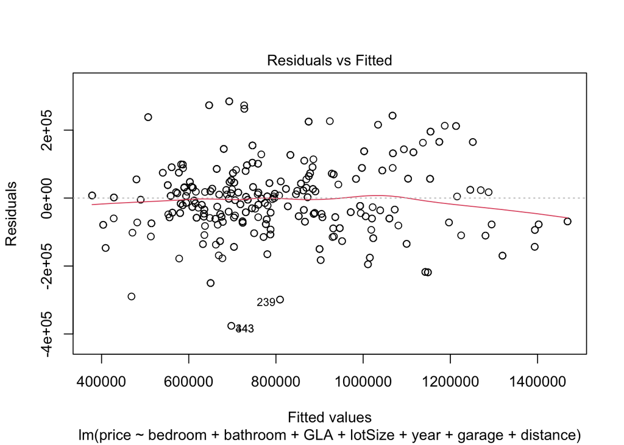

```r
par(mfrow = c(1,1))
plot(fit1,which = 1)
```

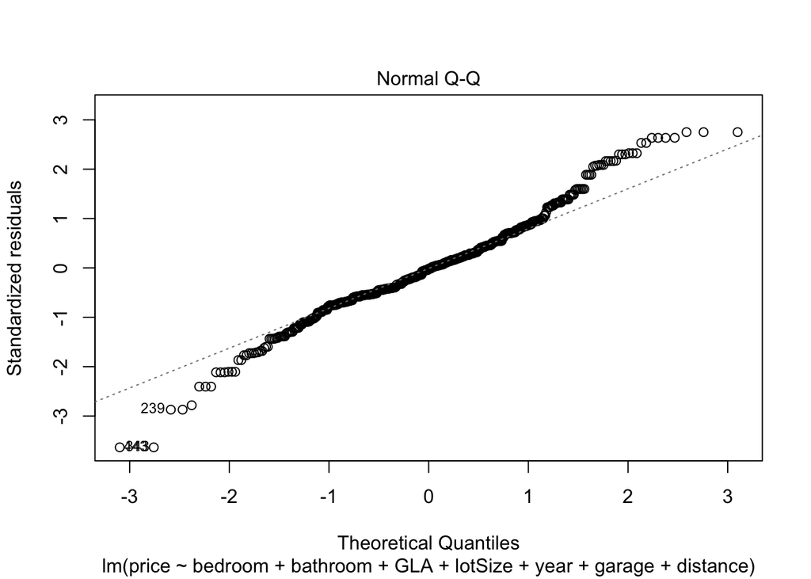

```r
plot(fit1,which = 2)
```

From the residual plot from the whole regression model, we can see the points nicely fill out this whole space, and the points distribute pretty evenly around the h=0; so, there is no violation of linearity and constant variance. However, we might violate the assumption of the normality because a few points are off the two sides of the qq-line.

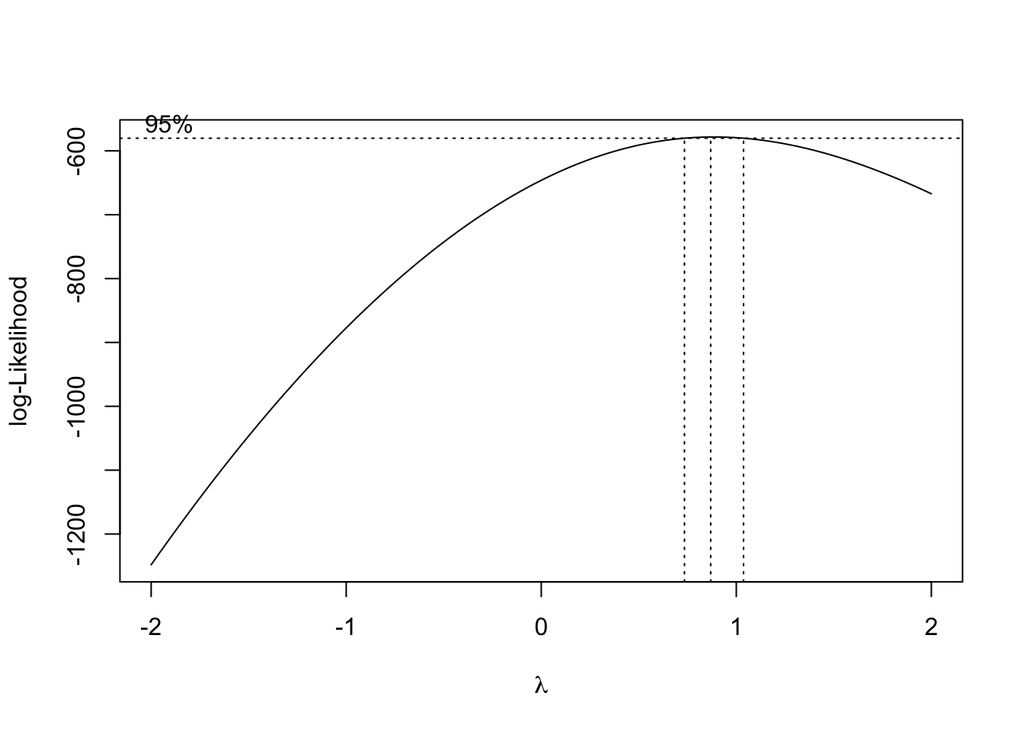

```r
boxcox(fit1)
```

To see if we can do a model transformation, I go throught a boxcox test, but the result shows the regressional model have the best format with the data. Thurs I will use a model selection procedure to help me enhance the efficiency of the model.

```r
cor(cbind(bedroom,bathroom,GLA,lotSize,year,garage,distance))
```

```
##              bedroom   bathroom        GLA   lotSize       year     garage
## bedroom   1.00000000  0.5927501  0.7396733 0.2752606 -0.1548826  0.2471471
## bathroom  0.59275012  1.0000000  0.7625565 0.1141760 -0.5475757  0.3052529
## GLA       0.73967326  0.7625565  1.0000000 0.4157561 -0.3517317  0.3221698
## lotSize   0.27526060  0.1141760  0.4157561 1.0000000  0.2554009  0.1878764
## year     -0.15488263 -0.5475757 -0.3517317 0.2554009  1.0000000 -0.2531509
## garage    0.24714714  0.3052529  0.3221698 0.1878764 -0.2531509  1.0000000
## distance  0.09915656  0.2389602  0.2985732 0.2664583 -0.4297449  0.2343699
##             distance
## bedroom   0.09915656
## bathroom  0.23896020
## GLA       0.29857317
## lotSize   0.26645834
## year     -0.42974489
## garage    0.23436994
## distance  1.00000000
```

```r
varname= c("bedroom", "bathroom", "GLA", "lotSize", "year", "garage", "distance")
X =cbind(bedroom,bathroom,GLA,lotSize,year,garage,distance)
lep=leaps(X,price,method='adjr2',nbest = 1,names=varname)
cbind(lep$which,'adjr2'= lep$adjr2)
```

```
##   bedroom bathroom GLA lotSize year garage distance     adjr2
## 1       0        0   1       0    0      0        0 0.7607810
## 2       0        0   1       1    0      0        0 0.7932166
## 3       0        0   1       1    0      1        0 0.8053295
## 4       1        0   1       1    0      1        0 0.8097377
## 5       1        1   1       1    0      1        0 0.8116855
## 6       1        1   1       1    0      1        1 0.8114360
## 7       1        1   1       1    1      1        1 0.8110849
```

```r
house_backward <- regsubsets(price~bedroom+bathroom+GLA+lotSize+year+garage+distance, data = house, method = "backward")
cbind(summary(house_backward)$which, "bic" = summary(house_backward)$bic)
```

```
##   (Intercept) bedroom bathroom GLA lotSize year garage distance       bic
## 1           1       0        0   1       0    0      0        0 -726.5847
## 2           1       0        0   1       1    0      0        0 -796.5285
## 3           1       0        0   1       1    0      1        0 -822.4368
## 4           1       1        0   1       1    0      1        0 -829.0183
## 5           1       1        1   1       1    0      1        0 -829.0926
## 6           1       1        1   1       1    0      1        1 -823.1762
## 7           1       1        1   1       1    1      1        1 -816.9849
```

```r
cbind(summary(house_backward)$which, "bic" = summary(house_backward)$adjr2)
```

```
##   (Intercept) bedroom bathroom GLA lotSize year garage distance       bic
## 1           1       0        0   1       0    0      0        0 0.7607810
## 2           1       0        0   1       1    0      0        0 0.7932166
## 3           1       0        0   1       1    0      1        0 0.8053295
## 4           1       1        0   1       1    0      1        0 0.8097377
## 5           1       1        1   1       1    0      1        0 0.8116855
## 6           1       1        1   1       1    0      1        1 0.8114360
## 7           1       1        1   1       1    1      1        1 0.8110849
```

```r
house_ex <- leaps(X,price, method = "Cp", nbest = 1, names = varname)
cbind(house_ex$which, "Mallows' Cp" = house_ex$Cp)
```

```
##   bedroom bathroom GLA lotSize year garage distance Mallows' Cp
## 1       0        0   1       0    0      0        0  138.866637
## 2       0        0   1       1    0      0        0   51.521422
## 3       0        0   1       1    0      1        0   19.598256
## 4       1        0   1       1    0      1        0    8.644017
## 5       1        1   1       1    0      1        0    4.378676
## 6       1        1   1       1    0      1        1    6.053921
## 7       1        1   1       1    1      1        1    8.000000
```

I build some new models for improvement using a model selection procedure. Both of the stepwise model selection procedure and Mallow’s CP selection procedure get the same result that the variable of distance and year are not efficient in the original model. Therefore, we could remove distance and year and use the remaining predictors to build a new model.

```r
fit<-lm(price~bedroom+bathroom+GLA+lotSize+garage)
summary(fit)
```

```
##
## Call:
## lm(formula = price ~ bedroom + bathroom + GLA + lotSize + garage)
##
## Residuals:
##     Min      1Q  Median      3Q     Max
## -381515  -58933   -3122   56471  287250
##
## Coefficients:
##              Estimate Std. Error t value Pr(>|t|)
## (Intercept) 1.027e+05  2.065e+04   4.971 9.12e-07 ***
## bedroom     2.738e+04  7.873e+03   3.477  0.00055 ***
## bathroom    2.557e+04  1.020e+04   2.507  0.01248 *
## GLA         2.288e+02  1.490e+01  15.361  < 2e-16 ***
## lotSize     1.117e+01  1.169e+00   9.554  < 2e-16 ***
## garage      3.302e+04  6.106e+03   5.408 9.81e-08 ***
## ---
## Signif. codes:  0 '***' 0.001 '**' 0.01 '*' 0.05 '.' 0.1 ' ' 1
##
## Residual standard error: 104600 on 510 degrees of freedom
## Multiple R-squared:  0.8135, Adjusted R-squared:  0.8117
## F-statistic:   445 on 5 and 510 DF,  p-value: < 2.2e-16
```

```r
anova(fit)
```

```
## Analysis of Variance Table
##
## Response: price
##            Df     Sum Sq    Mean Sq  F value    Pr(>F)
## bedroom     1 1.4097e+13 1.4097e+13 1289.045 < 2.2e-16 ***
## bathroom    1 3.0566e+12 3.0566e+12  279.495 < 2.2e-16 ***
## GLA         1 5.7264e+12 5.7264e+12  523.630 < 2.2e-16 ***
## lotSize     1 1.1304e+12 1.1304e+12  103.369 < 2.2e-16 ***
## garage      1 3.1985e+11 3.1985e+11   29.247 9.808e-08 ***
## Residuals 510 5.5774e+12 1.0936e+10
## ---
## Signif. codes:  0 '***' 0.001 '**' 0.01 '*' 0.05 '.' 0.1 ' ' 1
```

```r
s=summary(fit)
s$coefficients
```

```
##                 Estimate   Std. Error   t value     Pr(>|t|)
## (Intercept) 102667.65867 20653.829742  4.970878 9.116930e-07
## bedroom      27375.02403  7872.504738  3.477295 5.497741e-04
## bathroom     25567.26836 10198.130317  2.507054 1.248407e-02
## GLA            228.81790    14.895776 15.361261 4.816760e-44
## lotSize         11.16823     1.168918  9.554328 5.218325e-20
## garage       33019.70608  6105.640120  5.408066 9.807791e-08
```

```r
confint(fit)
```

```
##                    2.5 %       97.5 %
## (Intercept) 62090.600161 143244.71717
## bedroom     11908.493645  42841.55442
## bathroom     5531.752639  45602.78408
## GLA           199.553269    258.08254
## lotSize         8.871741     13.46472
## garage      21024.404513  45015.00766
```

The R-squared of the new model is 0.8135 and adjusted R-squared is 0.8117. Although the R-squared of the new model is a little smaller than the previous one, the adjusted R-squared improved a little, which shows more efficiency.

The F-statistic number is 445 on 5 and 510 DF and the corresponding p-value is < 2.2e-16, which also shows the highly linear relationship in our model.

In the new model, since I have removed the insignificant predictors, the remaining predictors show high significance.

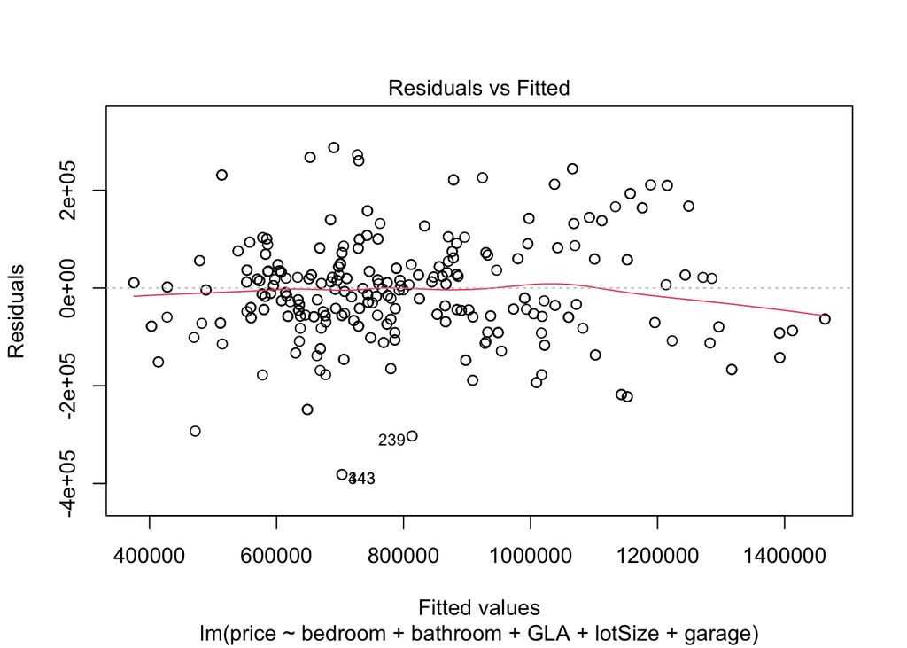

```r
plot(fit,which = 1)
```

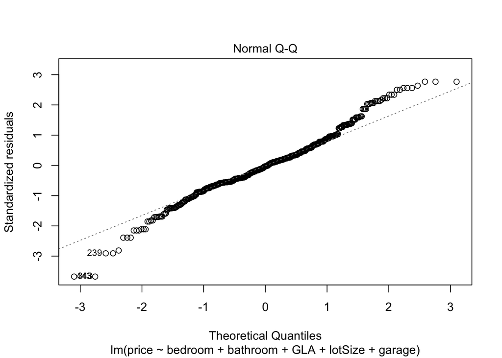

```r
plot(fit,which = 2)
```

From the residual plot from the new regression model, we can see the points nicely fill out this whole space, and the points distribute pretty evenly around the h=0; so, there is no violation of linearity and constant variance. However, it might still violate the assumption of the normality because a few points are off the two sides of the qq-line.

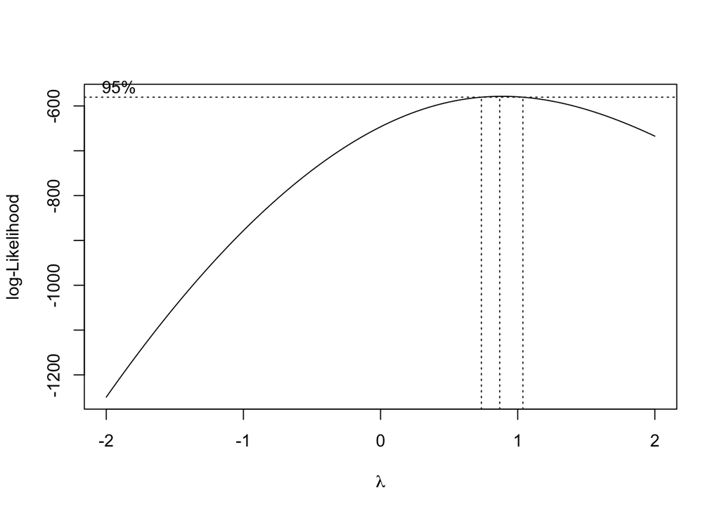

```r
boxcox(fit)
```

```r
the.SWtest1=shapiro.test(fit$residuals)
the.SWtest1$p.value
```

```
## [1] 4.894232e-06
```

**Conclusion**